# Movie Data by Yanyan Liu

> **data source**The file [`movies_merged`](https://s3.amazonaws.com/content.udacity-data.com/courses/gt-cs6242/project/movies_merged) contains a dataframe with the same name that has 40K rows and 39 columns. Each row represents a movie title and each column represents a descriptor such as `Title`, `Actors`, and `Budget`. I collected the data by querying IMDb’s API (see [www.omdbapi.com](http://www.omdbapi.com/)) and joining it with a separate dataset of movie budgets and gross earnings (unknown to you). The join key was the movie title. This data is available for personal use, but IMDb’s terms of service do not allow it to be used for commercial purposes or for creating a competing repository.

# Univariate Plots Section

> **data cleaning for Runtime** Runtime is shown in text format with hours and minutes, a function is used to turn the text data into numeric data.

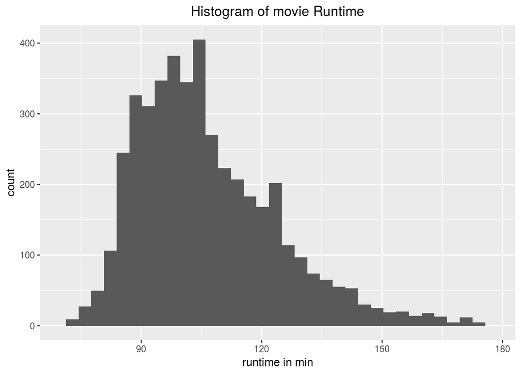

> **About Runtime**: when the lowest 1% and highest 1% of the data are excluded, the runtime distribution is close to normal, with most movies having runtime close to 100 min.

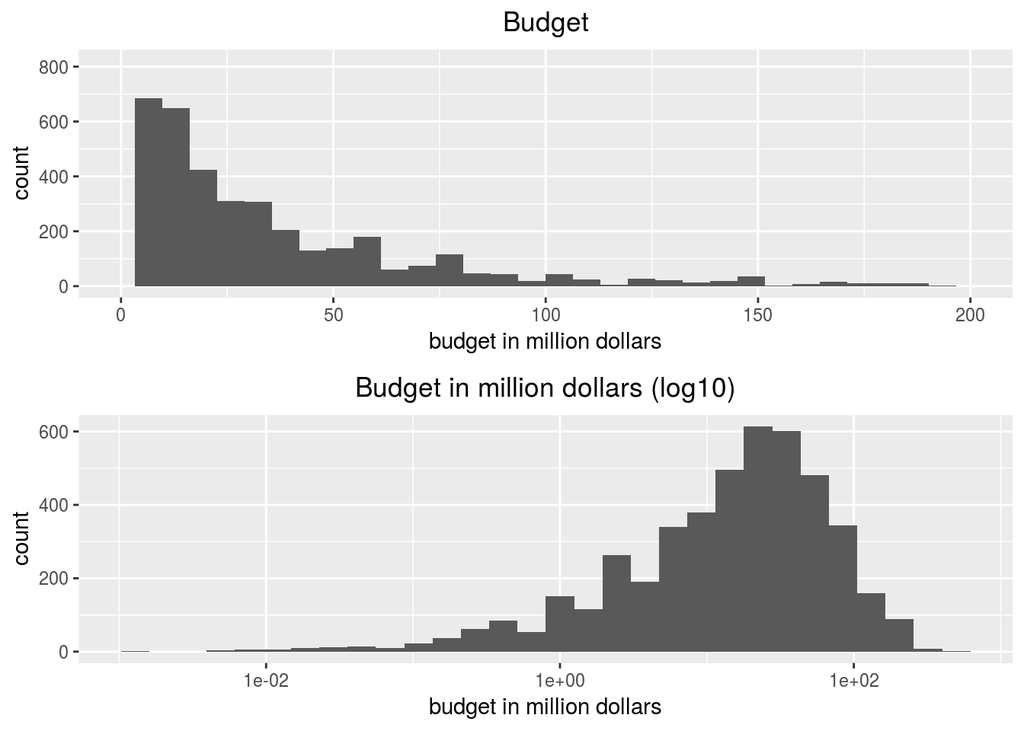

> **about budget**: budget is right skewed. log10 scaled budget looks normal. A new column named Budget_in_M is created to show budget in million dollars rather than dollars to clearly show on the million dollars scale.

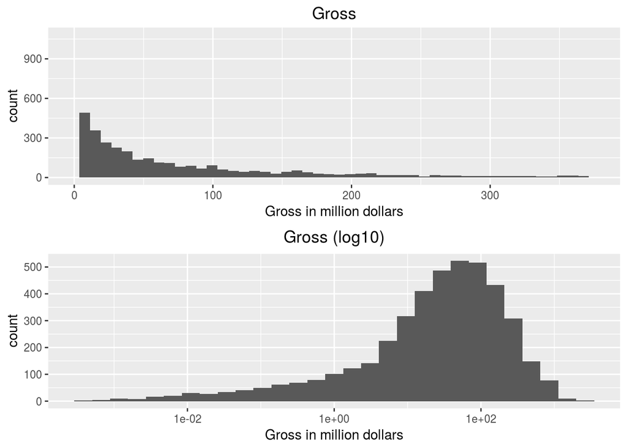

> **About Gross**: With the same reason as the budget, a new column called Gross_in_M is created. The gross on movie data is also skewed right. It has a very long tail, therefore the top 5 percentile data are excluded from the plotting using no log transformed data. log10 scaled gross looks normal.

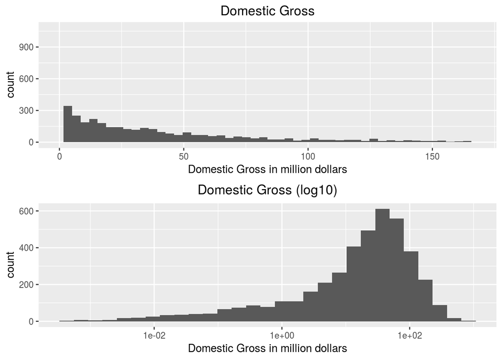

> **About Domestic Gross**: With the same reason as the budget, a new column called Domestic_Gross_in_M is created. The domestic gross on movie data is also skewed right. It has a very long tail, therefore the top 5 percentile data are excluded from the plotting using no log transformed data. log10 scaled gross looks normal. Domestic gross spread shapes looks very much like the total gross, just with a smaller gross value.

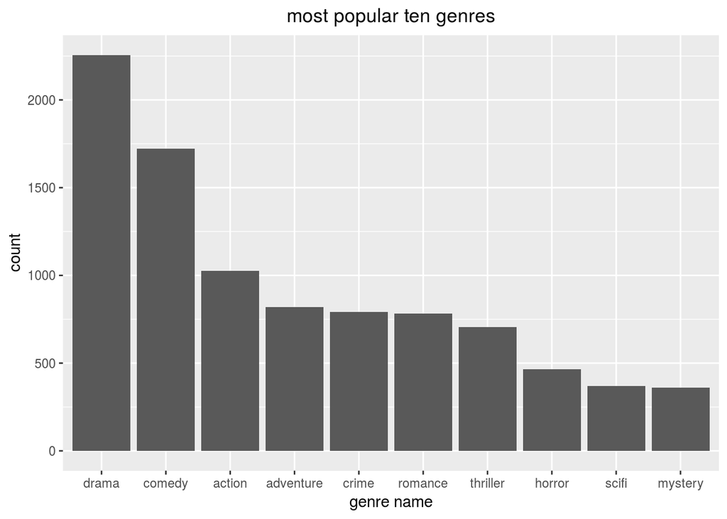

> **About the ten most popular genres**: From the bar plot, we can see the ten most popular genres, among which drama is the most popular one with more than 2000 movies over the years.

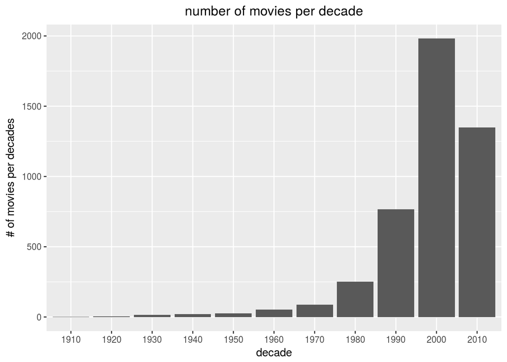

> **create new feature called month from released**: Original the Release column is string in date-like format, extract the month out. Change the level notations to simplified month notation, rather than using numeric number representation.

> **create new feature called date from released**: Original the Release column is string in date-like format, extract the date out.

# Univariate Analysis

### What is the structure of your dataset?

The original movie dataset is huge, more than 40,000 rows. The movie data set contains more than 4000 rows when the data are filtered by leaving out rows with NA values in gross and budget.It has a very interesting row called genre. The tm pacakage was used to do text mining, and found the most popular genres of the movies.

### What is/are the main feature(s) of interest in your dataset?

The most intersting features in the movies are: gross, budget, runtime, genre. I am intersted in seeing what are the characteric of movies that have relatively higher gross avenue.

### What other features in the dataset do you think will help support your investigation into your feature(s) of interest?

Other intersting feature include movie reward, movie rating.

### Did you create any new variables from existing variables in the dataset?

Yes, I created several new vairables. - the genre column was turned into a big binary matrix to determine the genre distribution of movies, and find the most popular movies’ genre. - the year column was original integer, I added a new categorical variable in which I bucket the years into decades. - newly created month feature from the original feature released - newly created date feature from the original feature released

### Of the features you investigated, were there any unusual distributions? Did you perform any operations on the data to tidy, adjust, or change the form of the data? If so, why did you do this?

# Bivariate Plots Section

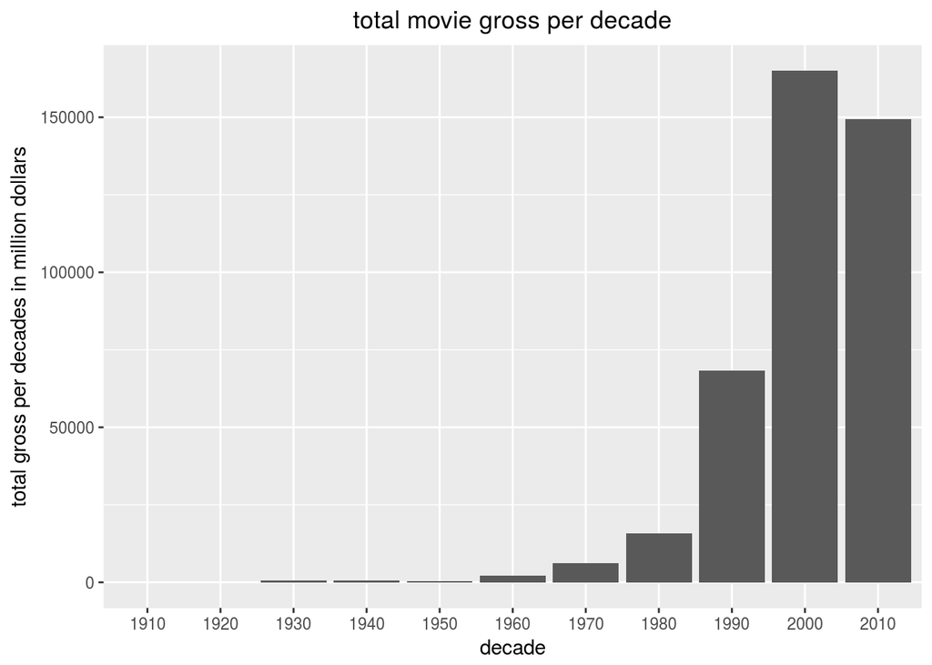

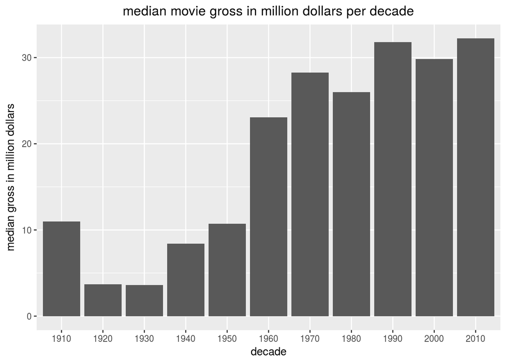

> **About median gross over the decades**: Since gross is right skewed and has long tail, I used graphed the median gross here. The median gross has the general of on the increase over the decades. But the gross went down during 1920 to 1950, that might be affected by various events, such as the great depression, the world wars, etc.The x label means the start year of the decade.

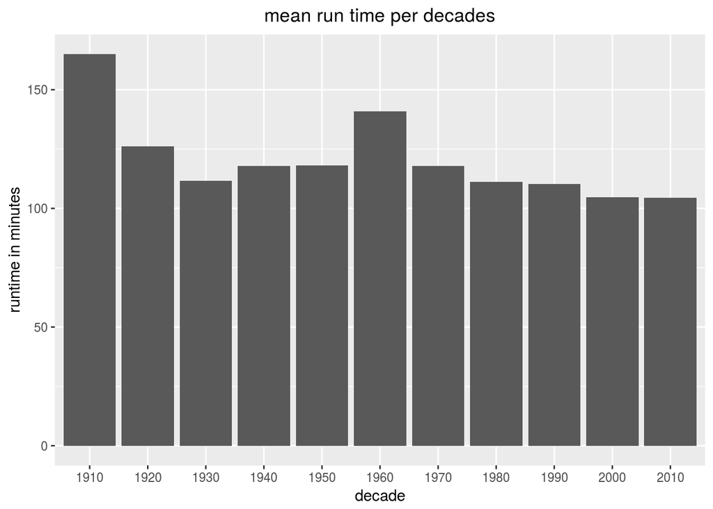

> **About the Runtime Over the decades**: we can see 100 years ago, the movies run much longer than nowadays, the movie length tend to decrease, but there is some kind of fluctuation around 1960. the x label means the start year of the decade.

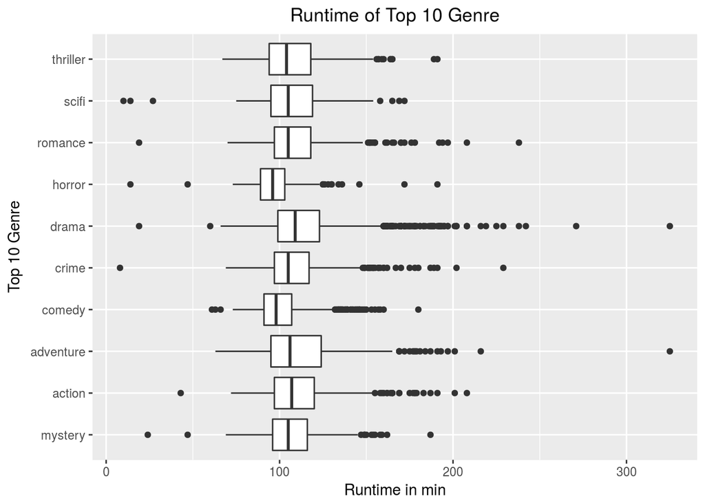

> **Runtime of 10 top genre**: we can see that horror and comedy has shorter runtime compared to others.

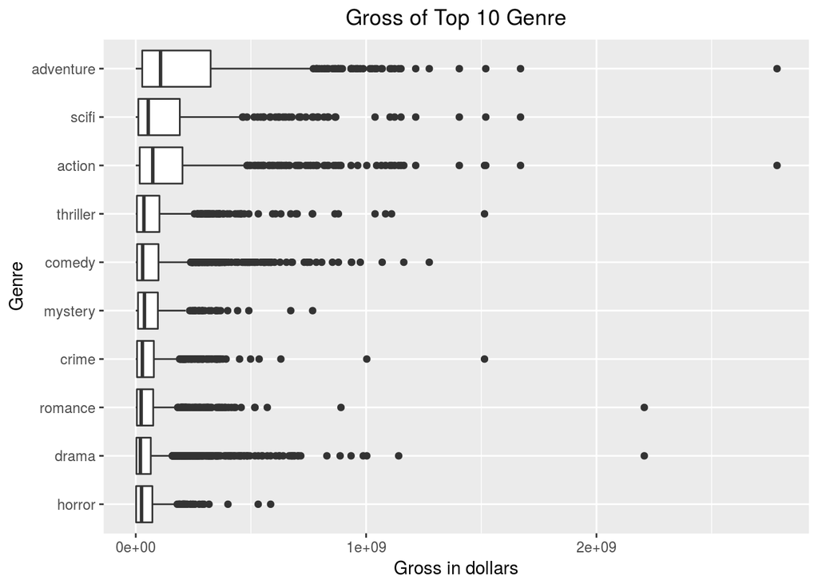

> **Gross of 10 top genres**: we can see that adventure has higher mean gross compared to tothers. But it also has relative big spread of the gross even for the middle 50% of the adventure movies.

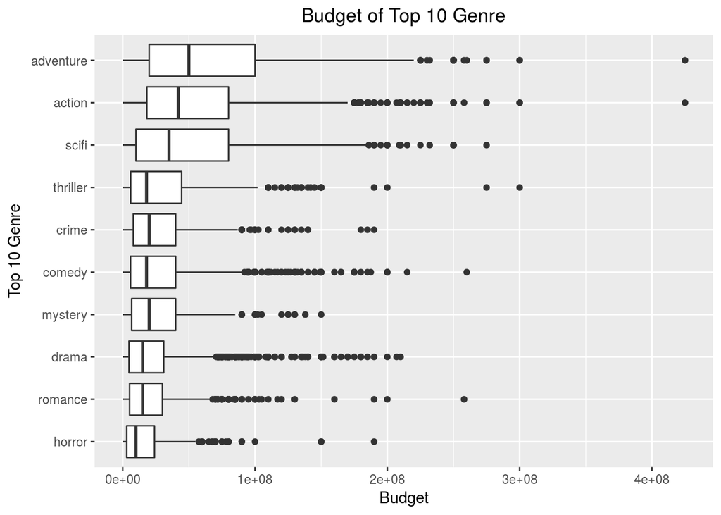

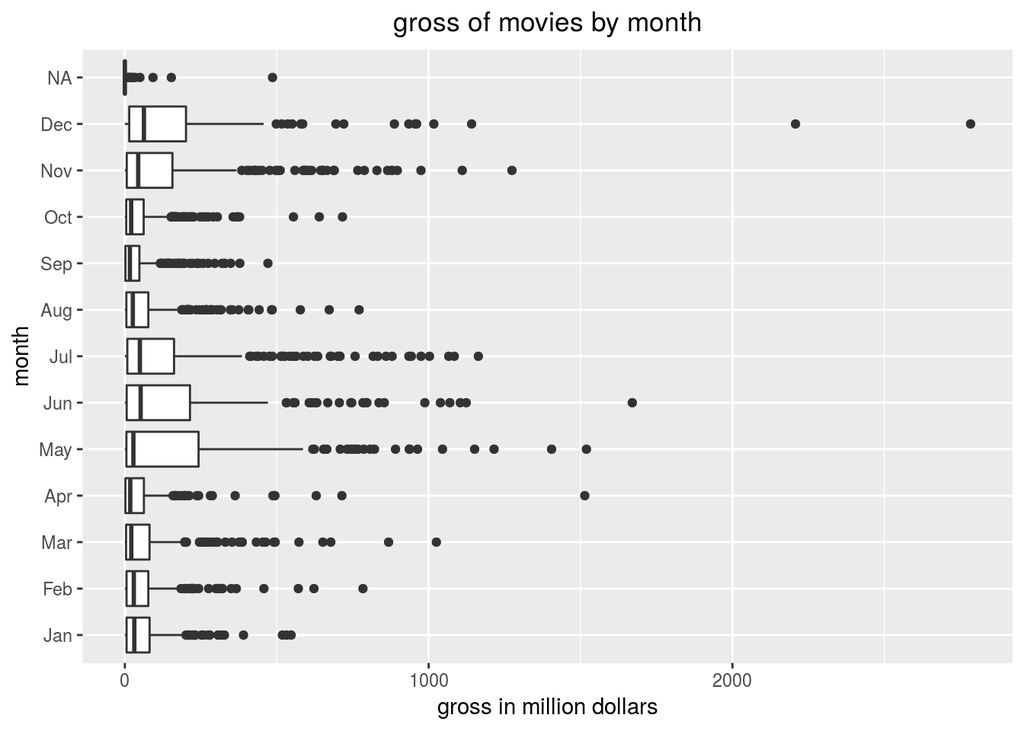

> **About the relationship of Gross and Released Month**: From the scatter plot we can spread of gross for movies released at different month varies a lot. Movies released in June, July Nov and Dec have higher mean gross.

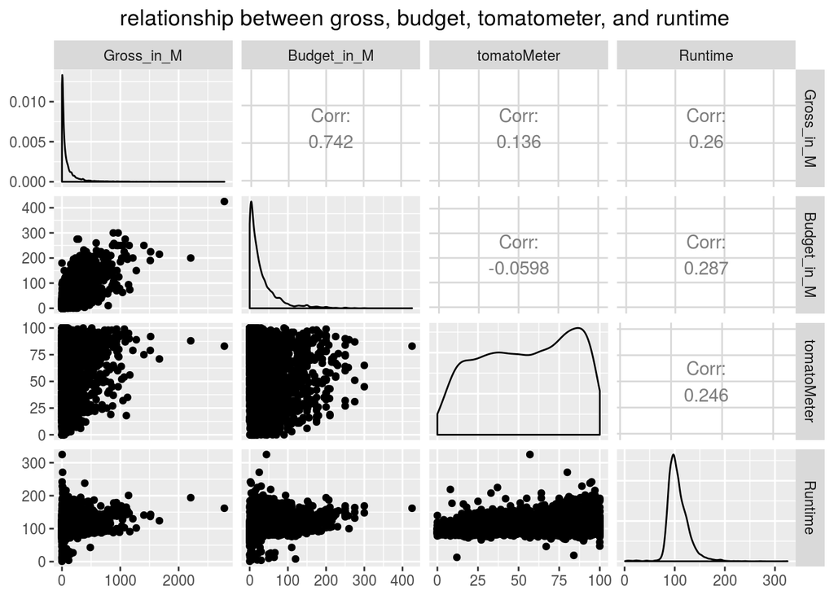

> **View Multiple Relationship With ggpairs**: we can see among the several features we have viewed individually, the strongest correlation is between budget and gross, which is 0.74. There is relative weak correlation between runtime and gross, budget and runtime, tomatometer and runtime, tomatometer and gross. Notice the gross and budget are in million dollars.

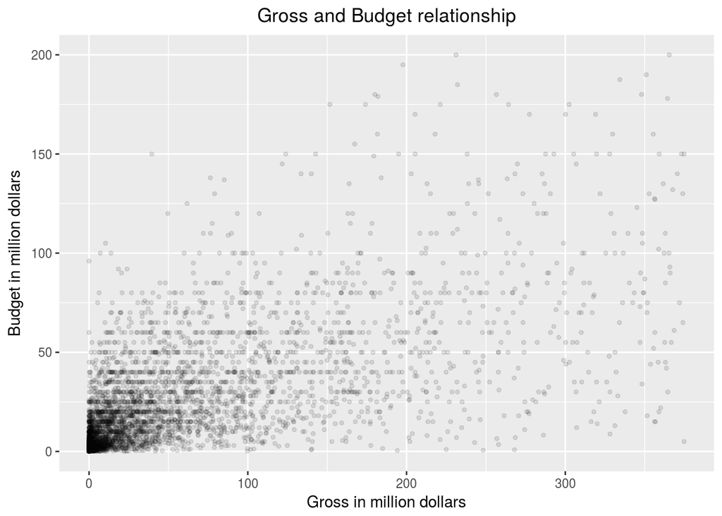

> **About the relationship of Gross and Budget**: From the scatter plot we can see there is positive correlation between gross and budget for movies.

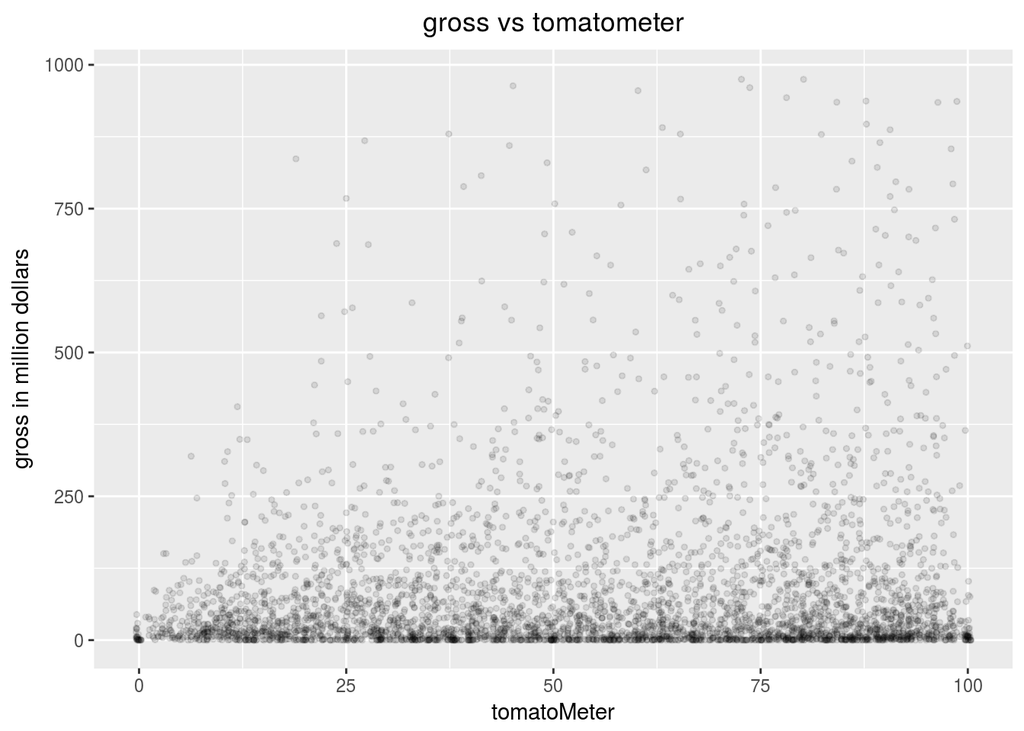

> **About the relationship of Gross and TomatoMeter**: Tomatometer is the scores the views gave, and it seems that movies with higher tomatometer score has higher gross, but it is severely overplotted, and it is hard to tell. Notice, 0.5% top gross are excluded from the plot so that plots are not too overpopulated at the bottom.

```
##
##  Pearson's product-moment correlation
##
## data:  df$Gross and df$tomatoMeter
## t = 8.8053, df = 4093, p-value < 2.2e-16
## alternative hypothesis: true correlation is not equal to 0
## 95 percent confidence interval:
##  0.1061608 0.1662826
## sample estimates:
##       cor
## 0.1363473
```

> **About correlation between gross and tomatometer**: the correlation test shows a weak positive relationship between gross and tomatometer score. Following the tomatometer score are seperated into 4 different buckets, and see how the relationship between gross and tomatometer score in each bucket.

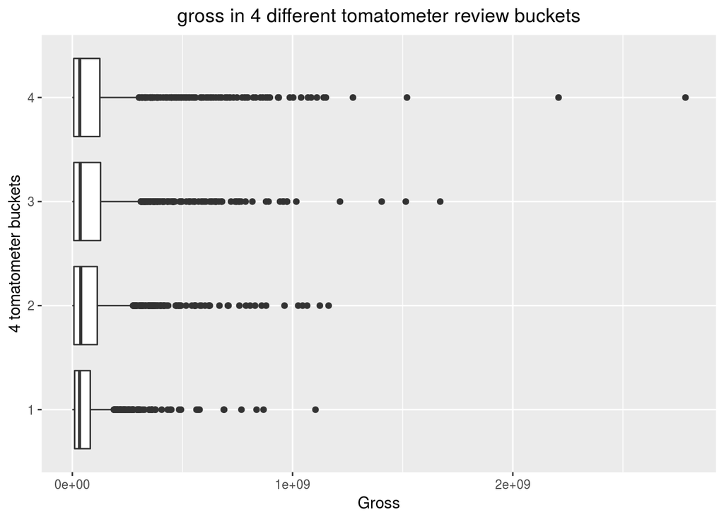

> **About the relationship of Gross and TomatoMeter review buckets**: The movies with 25% lowest reviews tend to have reletive mean gross, but for the other 75% percent of movies, the gross and review score did not have strong correlation with each other.

```
##
##  Pearson's product-moment correlation
##
## data:  df$Gross and df$Budget
## t = 74.687, df = 4556, p-value < 2.2e-16
## alternative hypothesis: true correlation is not equal to 0
## 95 percent confidence interval:
##  0.7285732 0.7546892
## sample estimates:
##       cor
## 0.7419125
```

> **Pearson’s correlation test on gross and budget shows strong correlation**: we can see the correlation is 0.74, and the p value is much smaller than 0.01.

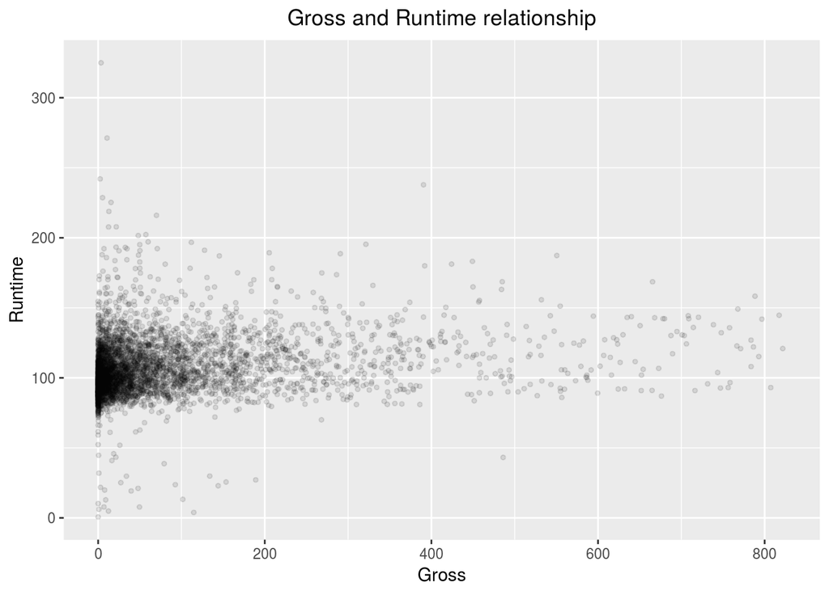

> **About the relationship of Gross and Runtime**: From the scatter plot we can see there is no strong correlation between gross and runtime for movies, as is that for gross and budget.

```
##
##  Pearson's product-moment correlation
##
## data:  df$Gross and df$Runtime
## t = 18.107, df = 4518, p-value < 2.2e-16
## alternative hypothesis: true correlation is not equal to 0
## 95 percent confidence interval:
##  0.2327295 0.2870957
## sample estimates:
##       cor
## 0.2601187
```

> **Pearson’s correlation test on gross and runtime shows positive correlation**: we can see the correlation is 0.26, and the p value is much smaller than 0.01.

```
##
##  Pearson's product-moment correlation
##
## data:  df$imdbRating and df$tomatoMeter
## t = 76.054, df = 4092, p-value < 2.2e-16
## alternative hypothesis: true correlation is not equal to 0
## 95 percent confidence interval:
##  0.7522956 0.7776942
## sample estimates:
##       cor
## 0.7652926
```

> **Pearson’s correlation test on tomatoMeter and imdbRating shows strong positive correlation**: we can see the correlation is 0.77, and the p value is much smaller than 0.01.

```
##
##  Pearson's product-moment correlation
##
## data:  df$Gross and df$tomatoMeter
## t = 8.8053, df = 4093, p-value < 2.2e-16
## alternative hypothesis: true correlation is not equal to 0
## 95 percent confidence interval:
##  0.1061608 0.1662826
## sample estimates:
##       cor
## 0.1363473
```

> **Pearson’s correlation test on Gross and tomatoMeter shows weak positive correlation**: we can see the correlation is 0.13, and the p value is much smaller than 0.01.

```
##
##  Pearson's product-moment correlation
##
## data:  df$Gross and df$imdbRating
## t = 14.332, df = 4512, p-value < 2.2e-16
## alternative hypothesis: true correlation is not equal to 0
## 95 percent confidence interval:
##  0.1805954 0.2364039
## sample estimates:
##       cor
## 0.2086695
```

> **Pearson’s correlation test on Gross and imdbRating shows weak positive correlation**: we can see the correlation is 0.21, and the p value is much smaller than 0.01.

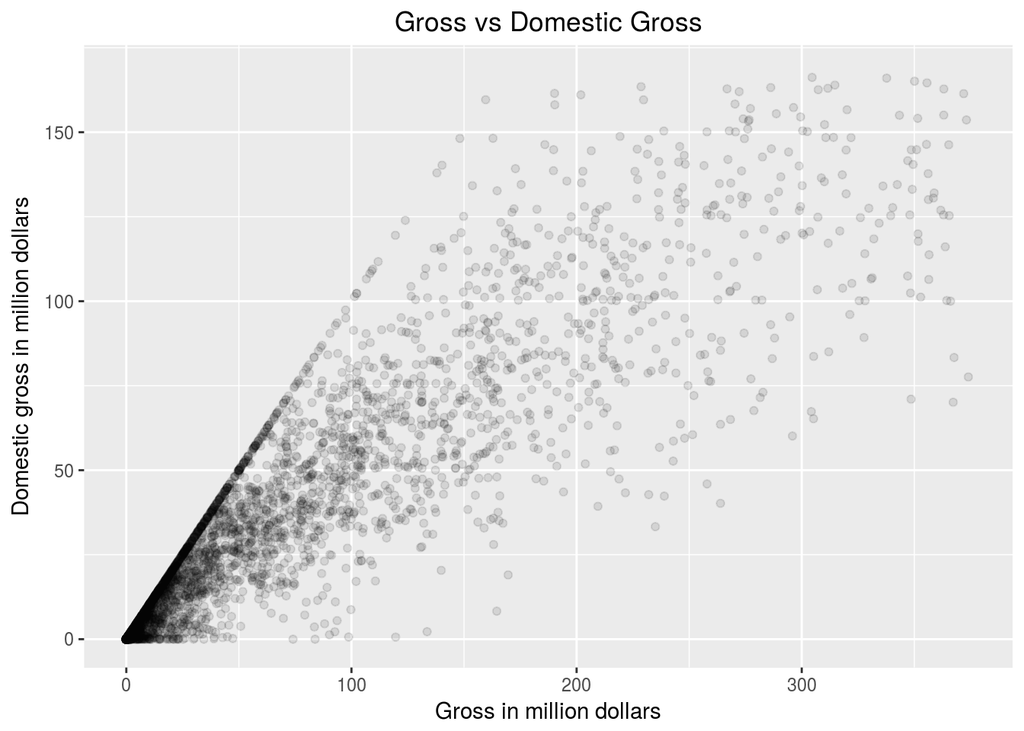

> **About gross vs domestic gross**: We can see there is strong positive correlation with gross and domestic gross, which is not a surprising fact.

```
##
##  Pearson's product-moment correlation
##
## data:  df$Gross and df$Domestic_Gross
## t = 185.85, df = 4556, p-value < 2.2e-16
## alternative hypothesis: true correlation is not equal to 0
## 95 percent confidence interval:
##  0.9364530 0.9432243
## sample estimates:
##       cor
## 0.9399311
```

> **About pearson correlation test on gross and domestic gross**: The statistics test shows there is very strong positive correlation between gross and domestic gross. The correlation is 0.94, and p value is smaller than 0.01.

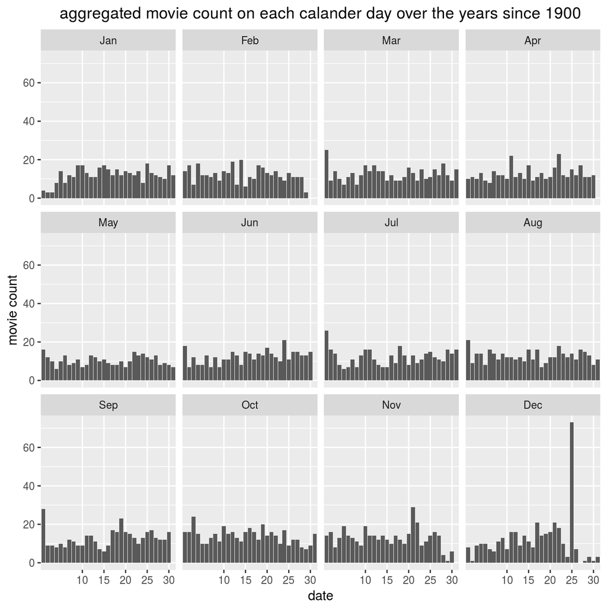

> **About movie released on each day**: We can see aggregated movie count on each calander day over the years since 1900 are almost evenly spread across, but there are some special days that have more movies released than other days,one such special day is Christmas day. On several days between christmas and several days after new year, the count of movies released are at the minimum. Also notice the last several days of Feb, it is pretty low, as only leap year has 29th day of the month.

# Bivariate Analysis

### Talk about some of the relationships you observed in this part of the investigation. How did the feature(s) of interest vary with other features in the dataset?

Feature of interest is Gross: we can see - budget is highly correclated with gross. This is not suprvising. - runtime has somewhat positive correlation with gross. - rating has very low positive correlation with gross, the movies with lowest tomatoMeter score also have lower gross, but for tomotatoMeter score outside of the lowest 25% bucket, the positive correlation between rate and gross is even weaker. - gross varies across different genres. Even in the same genres, we can also see a large spread of gross between movies.

### What was the strongest relationship you found?

- budget and gross are strongly positively correlated.

# Multivariate Plots Section

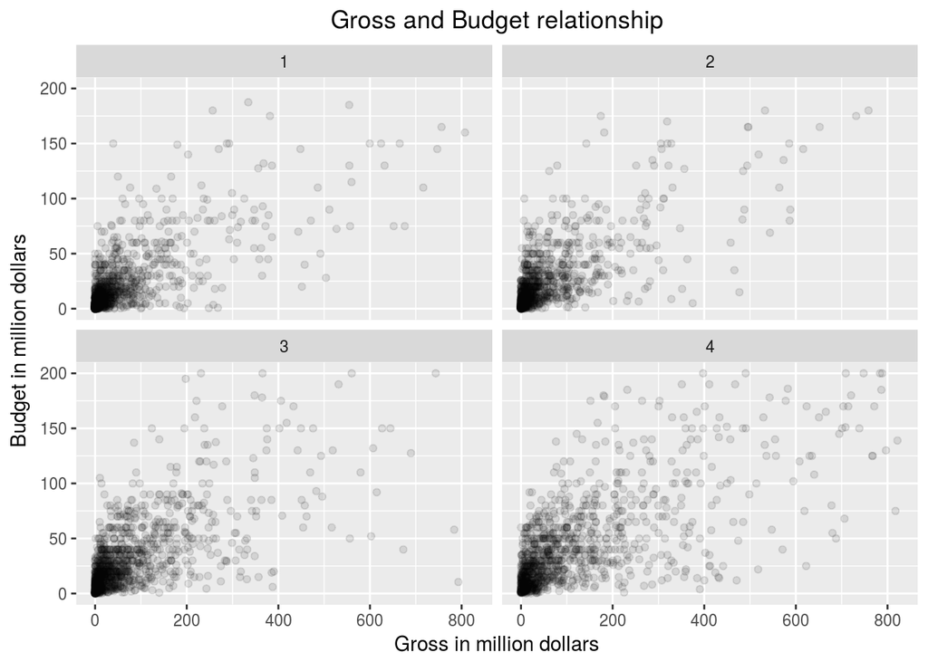

> **Gross and Budget relationship in different runtime bucket**: we can see in the fourth run time bucket, the scatter plot shows more strong positive relationship.

```
##
##  Pearson's product-moment correlation
##
## data:  df_rgb1$Gross and df_rgb1$Budget
## t = 34.687, df = 1233, p-value < 2.2e-16
## alternative hypothesis: true correlation is not equal to 0
## 95 percent confidence interval:
##  0.6733800 0.7299316
## sample estimates:
##       cor
## 0.7027643
```

> **for bucket 1, the correlation is 0.70**

```
##
##  Pearson's product-moment correlation
##
## data:  df_rgb2$Gross and df_rgb2$Budget
## t = 33.978, df = 1048, p-value < 2.2e-16
## alternative hypothesis: true correlation is not equal to 0
## 95 percent confidence interval:
##  0.6939017 0.7515845
## sample estimates:
##       cor
## 0.7240064
```

> **for bucket 2, the correlation is 0.72**

```
##
##  Pearson's product-moment correlation
##
## data:  df_rgb3$Gross and df_rgb3$Budget
## t = 31.538, df = 1134, p-value < 2.2e-16
## alternative hypothesis: true correlation is not equal to 0
## 95 percent confidence interval:
##  0.6513038 0.7133717
## sample estimates:
##       cor
## 0.6835716
```

> **for bucket 3, the correlation is 0.68**

```
##
##  Pearson's product-moment correlation
##
## data:  df_rgb4$Gross and df_rgb4$Budget
## t = 38.188, df = 1097, p-value < 2.2e-16
## alternative hypothesis: true correlation is not equal to 0
## 95 percent confidence interval:
##  0.7288731 0.7797470
## sample estimates:
##       cor
## 0.7554464
```

> **for bucket 4, the correlation is 0.76**

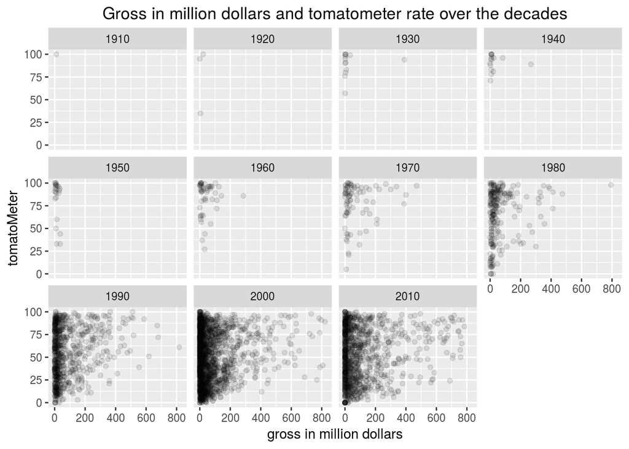

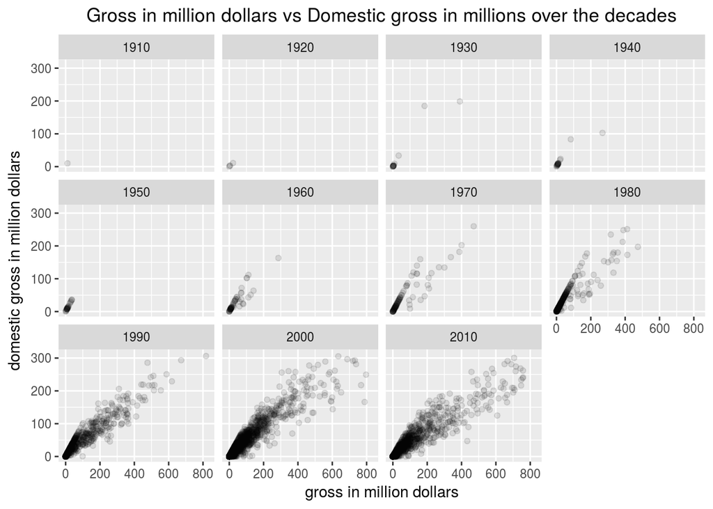

**About gross and domestic gross over the years**This plot shows the growth of the both gross and domestic gross over the decades since 1900. More and more gross are generated over the decades, and domestic gross shows a similar trend.

# Multivariate Analysis

### Talk about some of the relationships you observed in this part of the investigation. Were there features that strengthened each other in terms of looking at your feature(s) of interest?

For gross, if the movies have relative long runtime, and the budget is also high, the gross tends to be also higher. While if the runtime is a little bigger than the median, the budget and gross has relative lower positive correlation.

For gross and tomatometer over the decades, the rating system could just pretty new and therefore the movies released in the most recent three decades are very populated. For the movies released in the early years, there is not much rating records there, but if there is ,the scores tends to be hight, those movies could be very popular and famouse released in those specific decades.

For gross and domestic gross, over the decades, with gross increasing, domestic gross also increases.

### Were there any interesting or surprising interactions between features?

The relative lower correlation between gross and budget in the third runtime bucket is a little bit surprising.

### OPTIONAL: Did you create any models with your dataset? Discuss the strengths and limitations of your model.

# Final Plots and Summary

### Plot One

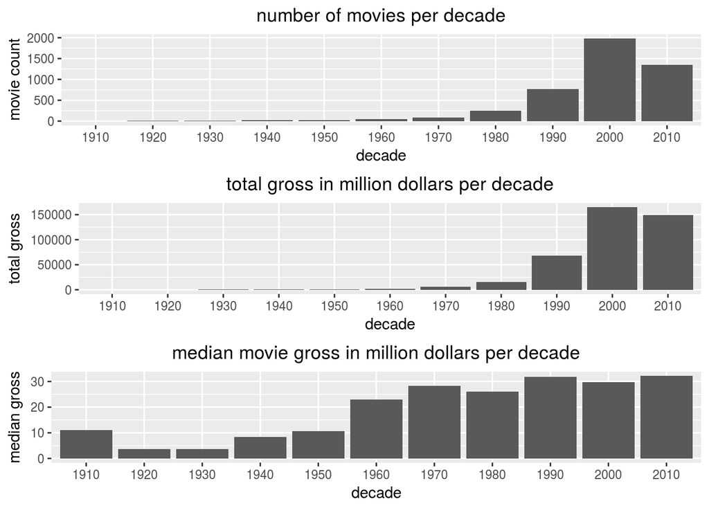

### Description One

This group of plots show the inreasing amount of movies released over the decades, the increasing amount of gross avenue brought by these movies, and the increasing trend of the medium gross for released movies over the decades. We can see, the movie industry is on the trend of continous growth since 1900. The decade of 2010 seems lower than 2000, that is because the record is not complete yet for this decade. Notice, not just the total count of movie and the total gross are on the increase, the medium gross brought by each movie are also on the trend of increase with small fluctuations.

### Plot Two

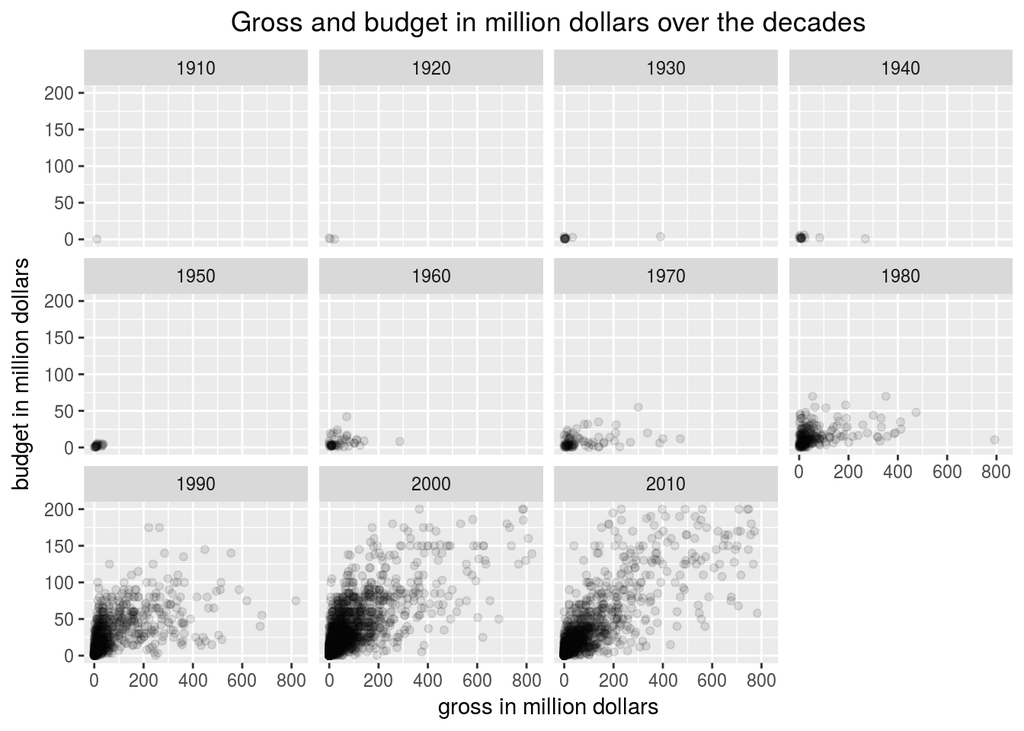

### Description Two

This plot shows the gross and budget relationship over the decades since 1900. We can see that both budgets nd gross are on increase over the years. It shows the growth of the movie industry over the years.

### Plot Three

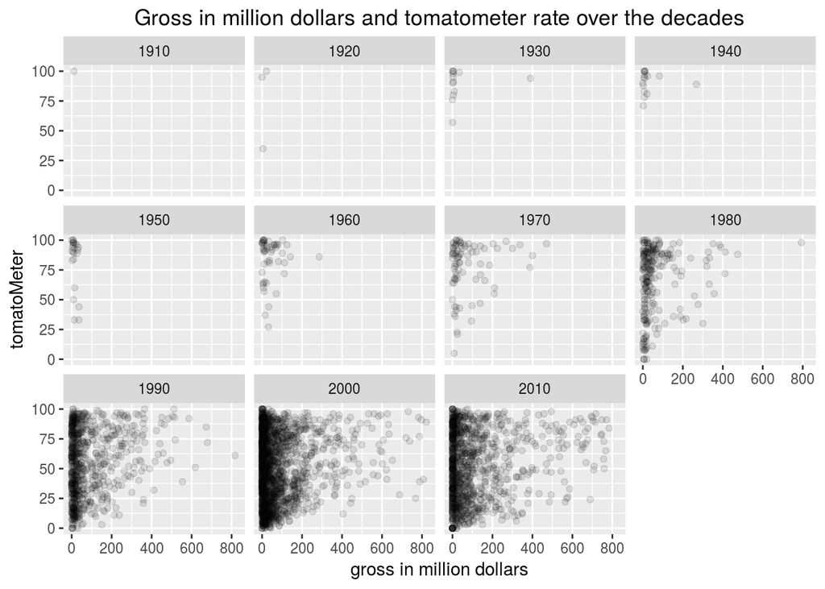

# Reflection

- Insights: found the top 10 popular geners, study the distribution of the gross and budget and runtime. Gross and budget have the strongest positve correlation, gross and runtime also have positive correlation. Adventure, scifi, and action are the top three genres with highest gross and budget. Movies released in early summer and during thanksgiving and christmas holiday seasons have higher gross income. And there are a lot of movies released on Chiristmas day!
- struggles: using tm do the text mining is not easy, and then how to use the created matrix for genre related study(such as runtime across genre, gross across genre, and budget acorss genre)
- using dplyr for data maniuplation went very well, really like the pipe, dplyr makes things easy filtering, selection, grouping, summarizing, etc.
- Further work: work on the rewards columns and study how the gross is correlated with rewards.The reward columns is text data, some more text mining will be required.